# Poisson Regression

Katherine Shim

November 11, 2018

### Poisson distribution

*The Poisson distribution is a useful model for counts and rates* Here a rate is count per some monitoring time * Some examples uses of the Poisson distribution + Modeling web traffic hits + Incidence rates + Approximating binomial probabilities with small $p$ and large $n$ + Analyzing contigency table data. A contingency table is a type of table in a matrix format that displays the (multivariate) frequency distribution of the variables.

### The Poisson mass function

- $X \sim Poisson(t\lambda)$ if
  $$P(X = x) = \frac{(t\lambda)^x e^{-t\lambda}}{x!}$$
  For $x = 0, 1, \ldots$.
- $\lambda$ is rate of counts per unit time and $t$ is the total time.
- The mean of the Poisson is $E[X] = t\lambda$, thus $E[X / t] = \lambda$
- The variance of the Poisson is $Var(X) = t\lambda$.
- The Poisson tends to a normal as $t\lambda$ gets large.

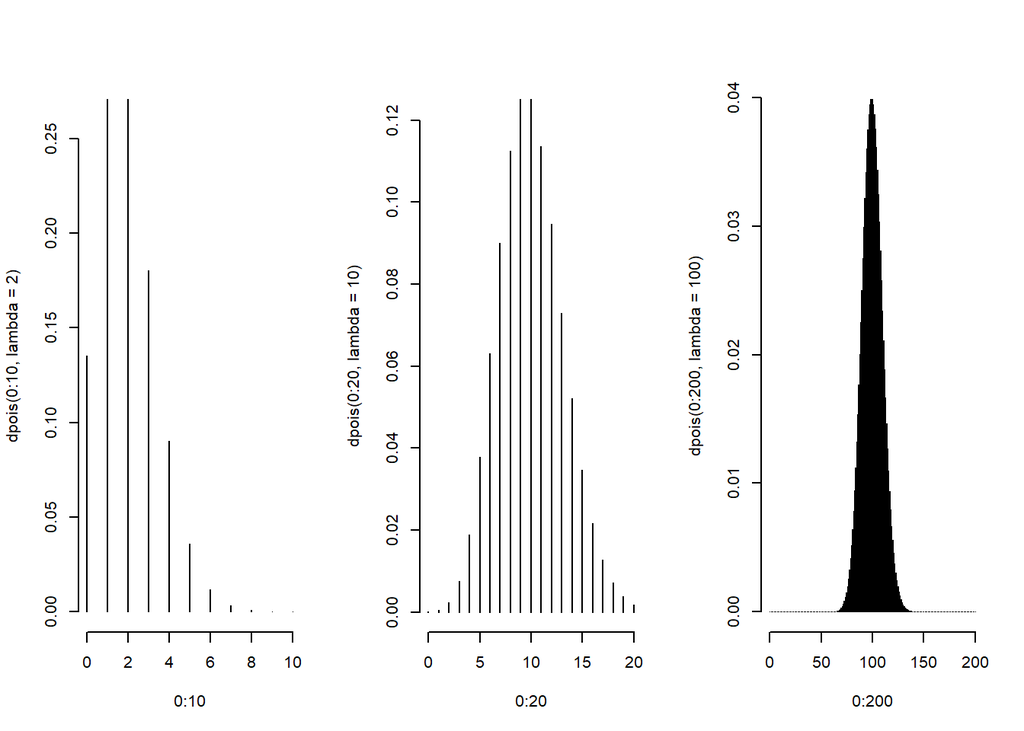

```r
par(mfrow = c(1, 3))
plot(0 : 10, dpois(0 : 10, lambda = 2), type = "h", frame = FALSE)
plot(0 : 20, dpois(0 : 20, lambda = 10), type = "h", frame = FALSE)
plot(0 : 200, dpois(0 : 200, lambda = 100), type = "h", frame = FALSE)
```

### Simulation for showing that the mean and variance are equal

```r
x <- 0 : 10000; lambda = 3
mu <- sum(x * dpois(x, lambda = lambda))
sigmasq <- sum((x - mu)^2 * dpois(x, lambda = lambda))
c(mu, sigmasq)
```

```
## [1] 3 3
```

### Poisson regression example: Website Traffict

- Since the unit of time is always one day, set $t = 1$ and then the Poisson mean is interpretted as web hits per day. (If we set $t = 24$, it would be web hits per hour).

### Linear regression

$$NH_i = b_0 + b_1 JD_i + e_i$$

- $NH_i$ - number of hits to the website
- $JD_i$ - day of the year (Julian day)
- $b_0$ - number of hits on Julian day 0 (1970-01-01)
- $b_1$ - increase in number of hits per unit day
- $e_i$ - variation due to everything we didn’t measure

### Poisson regression

- Taking the natural log of the outcome has a specific interpretation.
- Consider the model
  $$\log(NH_i) = b_0 + b_1 JD_i + e_i$$
- $NH_i$ - number of hits to the website
- $JD_i$ - day of the year (Julian day)
- $b_0$ - log number of hits on Julian day 0 (1970-01-01)
- $b_1$ - increase in log number of hits per unit day
- $e_i$ - variation due to everything we didn’t measure

### Exponentiating coefficients

- $e^{E[\log(Y)]}$ geometric mean of $Y$. This is a population geometric mean.
  - This is estimated by $e^{\frac{1}{n}\sum_{i=1}^n \log(y_i)} = (\prod_{i=1}^n y_i)^{1/n}$. The geometric mean of sample $y_i$ is exponentiate of the arithmatic mean of the log $y_i$.
- When you take the natural log of outcomes and fit a regression model, your exponentiated coefficients estimate things about geometric means.
- $e^{\beta_0}$ estimated geometric mean hits on day 0
- $e^{\beta_1}$ estimated relative increase or decrease in geometric mean hits per day
- There’s a problem with logs with you have zero counts, adding a constant works